# Wikipedia 2

# Table of Contents:

- Introduction
- Loading packages
- Reading the data
- Transforming the data
- Further Transformations.
- Visualizing the data

# Introduction.

The purpose of this project is to mine data from the [Wikipedia](http://en.wikipedia.org/wiki/) website and perform classification. This project was performed with the guidance of the following websites: [Manipulate clusters of texts with R](https://dzone.com/articles/manipulate-clusters-of-texts) [R : Categorization / Clustering Of Wikipedia Articles Using R](http://brazenly.blogspot.gr/2015/02/r-categorization-clustering-of.html) [Text mining in R - Automatic categorization of Wikipedia articles](https://www.r-bloggers.com/text-mining-in-r-automatic-categorization-of-wikipedia-articles/)

# Loading Packages.

The first step towards analyzing the data is Loading the packages:

```r
library(tm)
library(stringi)
library(proxy)
```

```r
library(wordcloud)
```

# Reading wikipedia.

The next step is reading wikipedia. To perform this analysis I chose 9 articles of 3 different topics. The articles are: - From Geography: Alaska, California, Florida - From Mathematics: Square, Rectangular, Rhombus - From NBA: Bulls, Bucks, Spurs And then set up the connection with wikipedia and pulled all information:

```r
wiki <- "http://en.wikipedia.org/wiki/"
titles <- c("Florida",
           "California",
           "Alaska",
           "Rectangular", "Square", "Rhombus",
           "Bulls", "Bucks", "Spurs")
articles <- character(length(titles))
for (i in 1:length(titles)) {
  articles[i] = stri_flatten(readLines(stri_paste(wiki, titles[i])), col = " ")
}
```

# Transforming Data.

Then we transform the “articles” into a Corpus.

```r
docs <- Corpus(VectorSource(articles))
```

```r
docs <- tm_map(docs, function(x) stri_replace_all_regex(x, "<.+?>", " "))
docs <- tm_map(docs, function(x) stri_replace_all_fixed(x, "\t", " "))
docs <- tm_map(docs, stripWhitespace)
docs <- tm_map(docs, removeWords, stopwords("english"))
docs <- tm_map(docs, removePunctuation)
docs <- tm_map(docs, tolower)
docs <- tm_map(docs, PlainTextDocument)
```

# Further transformations.

After Removing all unnecessary terms we can transform the Corpus above into a Document Term Matrix.

```r
docsTDM <- DocumentTermMatrix(docs)
```

In order to proceed with our analysis we have to convert the Document Term Matrix into a matrix.

```r
docsTDM2 <- as.matrix(docsTDM)
```

Then we check the dimensions of the matrix

```r
dim(docsTDM2)
```

```
## [1]     9 10989
```

```r
frequency <- colSums(docsTDM2)
frequency <- sort(frequency, decreasing=TRUE)
mots=frequency[frequency>20]
s=docsTDM2[1,which(colnames(docsTDM2) %in% names(mots))]
for(i in 2:nrow(docsTDM2)) s=cbind(s,docsTDM2[i,which(colnames(docsTDM2) %in% names(mots))])
colnames(s) <- titles
```

# Visualizing variables.

Then we can use a PCA to visualise the ‘variables’:

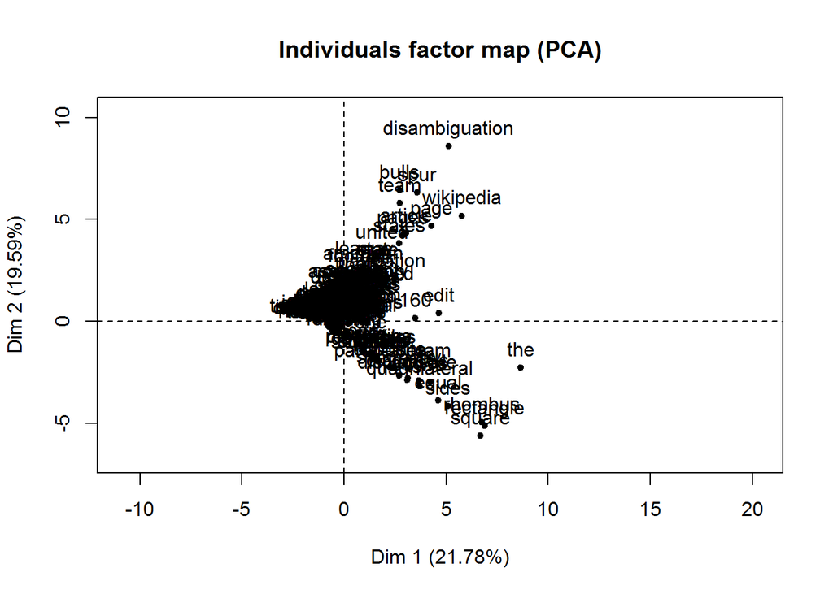

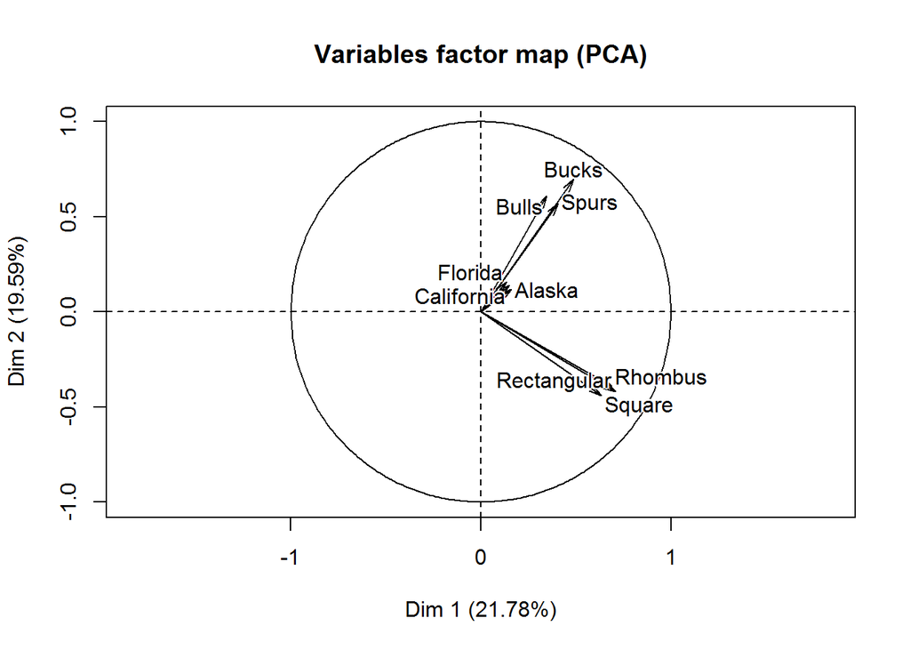

```
## **Results for the Principal Component Analysis (PCA)**
## The analysis was performed on 359 individuals, described by 9 variables
## *The results are available in the following objects:
##
##    name               description
## 1  "$eig"             "eigenvalues"
## 2  "$var"             "results for the variables"
## 3  "$var$coord"       "coord. for the variables"
## 4  "$var$cor"         "correlations variables - dimensions"
## 5  "$var$cos2"        "cos2 for the variables"
## 6  "$var$contrib"     "contributions of the variables"
## 7  "$ind"             "results for the individuals"
## 8  "$ind$coord"       "coord. for the individuals"
## 9  "$ind$cos2"        "cos2 for the individuals"
## 10 "$ind$contrib"     "contributions of the individuals"
## 11 "$call"            "summary statistics"
## 12 "$call$centre"     "mean of the variables"
## 13 "$call$ecart.type" "standard error of the variables"
## 14 "$call$row.w"      "weights for the individuals"
## 15 "$call$col.w"      "weights for the variables"
```

```r
PCA(s)
```

Finally, we perform text classification with hclust() function and plot them with plot() function.

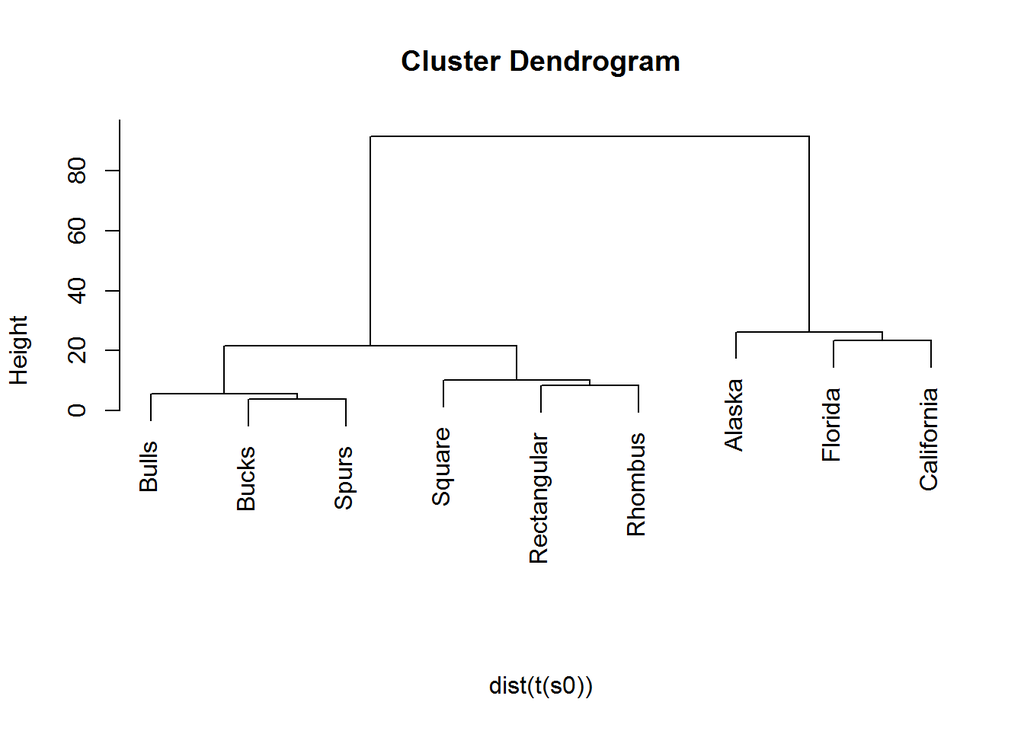

```r
s0=s/apply(s,1,sd)
h <- hclust(dist(t(s0)), method = "ward.D")
plot(h, labels = titles, sub = "")
```